# HW01-Ch4-XinqianCai

Xinqian Cai

2022/1/16

##Q1 1. What is a conditional distribution? A conditional distribution is the distribution of one variable given the value of another variable.

A: The conditional mean of depression decreases as Income increases.

2. Does the graph indicate that lower income causes depression? Why or why not?

##Q3 3. The below fictional table depicts data collected from 3000 university students on their classification (Freshman, Sophomore, Junior, Senior) and whether or not they receive financial aid. The table shows a cross tabulation of classification and receipt of financial aid.

FinancialAid Freshman Sophomore Junior Senior Yes 508 349 425 288 No 371 337 384 338

1. Calculate the probability of receiving financial aid given that a student is a Senior.

```r
prob_a<-288/(288+338)
prob_a
```

```
## [1] 0.4600639
```

The probability of receiving financial aid given that a student is a Senior is about 46%.

2. Calculate the probability that a student is a Senior given that they receive financial aid.

```r
prob_b<-288/(508+349+425+288)
prob_b
```

```
## [1] 0.1834395
```

The probability that a student is a Senior given that they receive financial aid is about 18.344%.

3. Calculate the probability of receiving financial aid given that a student is a Freshman.

```r
prob_c<-508/(508+371)
prob_c
```

```
## [1] 0.5779295
```

The probability of receiving financial aid given that a student is a Freshman is about 57.8%.

##Q4 4. Describe two advantages and one disadvantage of using line-fitting methods as opposed to calculating local means.

A: There are two advantages of using line-fitting methods: the first one is that it gives us the conditional mean of Y for anyvalue of X we can think of, even if we don’t have data for that psecific value; the second advantage is that it can help us cleanly describe the relationship between Y and X. For example, if the slope coeefficient on X is positive, then we could say that X and Y are positively related; if the slope is negative, then we could say thawt X and Y are negatively related. The disadvantage is that fitting a line requires to fit a line. So, we need to figure out what kind of line is the best to describe the relationship. If we start with a wrong shape, the estimate of the conditional mean will be all wrong, too.

##Q5 5. Consider the line of best fit: Y = 4 - 3.5X.

1. What is the conditional predicted mean of Y when X=6?

```r
y1<- 4-(3.5*6)
y1
```

```
## [1] -17
```

The conditional predicted mean of Y is -17 when x =6.

2. What is the conditional predicted mean of Y when X=-2?

```r
y2<- 4-(3.5*(-2))
y2
```

```
## [1] 11
```

The conditonal predicted mean of Y is 11 when x =-2.

##Q6 6. Which of the following terms describes a measurement of how much two variables vary with each other?

A: c. Covariance.

1. Variance
2. Conditional mean
3. Covariance
4. Local mean

##Q7 7. What is the difference between covariance and correlation? The covariance evaluates how much two variables move together or apart; while the correlation is an indicator of how strongly these 2 variables are related, provided other conditions are constant.

The covariance values can range from -∞ to ∞; while the correlation values range from -1 to +1.

Besides, correlation is deduced by dividing the calculated covariance with standard deviation of the two variables. So the scalability will not affect correlation but affect covairiance.

And correlation is unitless.

A: a straight line

A: A curve first goes down and then goes up.

3. Which shape is a better fit for the data, and how can you tell? A: The curvy line seems better fit for the data because each observed intelligence value is closer to the predicted value of the curve than the predicted value of the straigtline.
4. For Figure A, describe the residuals for different ranges of math exam scores. Are the observed data below or above the line/curve? Are the residuals evenly scattered around the line/curve?

All the residuals are not evenly scattered around the line.

##Q9 9. The below table contains fictional data on 5 employees from a company, repotting on how well they get along with their coworkers (GetAlong) and their level of job satisfaction (Satisfaction). The Prediction variable is the predicted satisfaction level, or the conditional mean of satisfaction, for each value of GetAlong derived after fitting a line of best fit using ordinary least squares estimation.

1. Fill in the “residual” column.

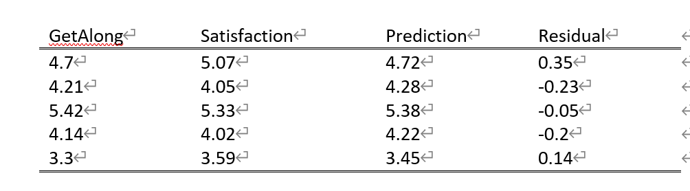

```r
knitr::include_graphics("residuals.png")
```

2. Describe how ordinary least squares uses residuals when fitting a line. OLS first squares the residuals and then adds up all the squared residuals across all the data, and finally picks the line with the smallest sum of squared residuals.

##Q10 10. We’ll be thinking here about the process of controlling for a variable. Consider the example: What is the relationship between first generation status and graduation rate in a population of college students?

1. Give an example of at a variable that might explain why first generation status and graduation rate are correlated other than one causing the other.

A: Family income might affect both the first generation status and graduation rate at the same time. With greater family income, probably the less possible a student will be the first generation; with greater family income, probably the higher graduation rate is. Therefore, we had better say first generation status and graduation rate are correlated other than one causing the other.

2. Describe in five steps how you would subtract out the part of the first-generation/graduation-rate relationship that is explained by the variable you listed in part a.
1. Get the mean of graduation rate conditional on family income
2. Subtract out that conditional mean to get the residual of graduation rate.
3. Get the mean of first-generation status conditional on family income.
4. Subtract out the conditional mean to get the residual of first generation status.
5. Describe the relationship between the residual of graduation rate and the residual of first generation status.
3. How would you interpret the first-generation/graduation-rate relationship you get after performing the steps in part b?

After performing the steps in part b, we are getting the relationship between the residual of first generation conditional on family income and the residual of graduation rate conditional on family income, which means we are getting the mean of graduation rate conditional on first generation status all conditional on family income. And we have controlled for family income, washing out the part of the first-generation/graduation-rate relationship that is explained by family income.